# Exploring data (EDA, ds4psy)

Hansjörg Neth, SPDS, uni.kn

2018 11 27

# Introduction

This file contains **essential commands** from [Chapter 7: Exploratory data analysis](https://r4ds.had.co.nz/exploratory-data-analysis.html) of the textbook [r4ds](http://r4ds.had.co.nz) and corresponding examples and exercises. A command is considered “essential” when you really need to *know* it and need to know *how to use* it to succeed in this course.

All [ds4psy](http://rpository.com/ds4psy/) essentials so far:

| Nr. | Topic |
| --- | --- |
| 0. | [Syllabus](http://rpository.com/ds4psy/) |
| 1. | [Basic R concepts and commands](http://rpository.com/ds4psy/essentials/basics.html) |
| 2. | [Visualizing data](http://rpository.com/ds4psy/essentials/visualize.html) |
| 3. | [Transforming data](http://rpository.com/ds4psy/essentials/transform.html) |
| 4. | **Exploring data (EDA)** |
| +. | [Datasets](http://rpository.com/ds4psy/essentials/datasets.html) |

## Course coordinates

- Taught at the [University of Konstanz](https://www.uni-konstanz.de/) by [Hansjörg Neth](http://neth.de/) (h.neth@uni.kn, [SPDS](https://www.spds.uni-konstanz.de/), office D507).
- Winter 2018/2019: Mondays, 13:30–15:00, C511.
- Links to current [course syllabus](http://rpository.com/ds4psy/) | [ZeUS](https://zeus.uni-konstanz.de/hioserver/pages/startFlow.xhtml?_flowId=detailView-flow&unitId=5101&periodId=78&navigationPosition=hisinoneLehrorganisation,examEventOverviewOwn) | [Ilias](https://ilias.uni-konstanz.de/ilias/goto_ilias_uni_crs_809936.html)

## Preparations

Create an R script (`.R`) or an R-Markdown file (`.Rmd`) and load the R packages of the `tidyverse`. (Hint: Structure your script by inserting spaces, meaningful comments, and sections.)

```r
## Exploring data (EDA) | ds4psy
## 2018 11 26
## ----------------------------

## Preparations: ----------

library(tidyverse)

## 1. Topic: ----------

# etc.

## End of file (eof). ----------
```

# Exploring data

## Introduction

In the following, we refine and use what we have learned so far to explore data. Practically, this session combines what we have learned about `ggplot2` (in [Chapter 3: Data visualization](http://r4ds.had.co.nz/data-visualisation.html)) and about `dplyr` (in [Chapter 5: Data transformation](https://r4ds.had.co.nz/transform.html)) to explore datasets.

Important concepts in this session include:

- missing values (`NA`)
- different measurement levels of variables (e.g., categorical vs. continuous)

See [Chapter 7: Exploratory data analysis (EDA)](http://r4ds.had.co.nz/exploratory-data-analysis.html) and the links provided below for more detailed information.

## What is EDA?

According to [Grolemund & Wickham (2017, Chapter 7)](http://r4ds.had.co.nz/exploratory-data-analysis.html) *exploratory data analysis* (EDA) primarily is a state of mind. Rather than following a strict set of rules, EDA is an initial phase of familiarising yourself with a new data set by actively engaging in an iterative cycle during which you

- Generate questions about data.
- Search for answers by visualising, transforming, and modelling data.
- Use answers to refine your questions and/or generate new questions.

Philosophically speaking, EDA is a data scientist’s way of doing hermeneutics (see [Wikipedia](https://en.wikipedia.org/wiki/Hermeneutics) or [The Stanford Encyclopedia of Philosophy](https://plato.stanford.edu/entries/hermeneutics/) for definitions) to get a grip on data.

The goal and purpose of EDA is to gain an overview of a dataset. This includes an idea of its dimensions and the number and types of variables contained in the data, but also a more detailed idea of the distribution of variables, their potential relations to each other, and potential problems (e.g., missing values or outliers).

When using the tools provided by the `tidyverse`, the fastest way to gain insights into a dataset is a series of `dplyr` calls and `ggplot2` graphs. However, creating good graphs is both an art and a craft. The key to creating good graphs requires answering 2 sets of questions:

1. Knowing the *intended type of plot*. This includes answering *functional* questions like
   - What is the *goal* or *purpose* of this plot?
   - What are *possible* plot types for this purpose?
   - Which of these would be the most *appropriate* plot here?
2. Knowing the *number* and *type* of variables to be plotted. This includes answering *data-related* questions like
   - How many variables are to be plotted and how are they mapped to dimensions and aesthetics?
   - Are these variables categorical or continuous?
   - Do some variables control or qualify (e.g., group) the values of others?

Even when these questions are answered, creating beautiful and informative graphs with `ggplot` requires dedicated practice, experience, and trial-and-error experimentation. In addition, an new dataset is rarely in a condition and shape to directly allow plotting. Instead, we typically have to interleave commands for plotting and transforming data to wrangle variables into specific shapes or types. Thus, calls to `ggplot2` usually occur in combination with other `tidyverse` commands (stemming from `dplyr`, `forcats`, `tidyr`, `readr`, `tibble`, etc.).

What needs to be done in any specific case depends on the details of the data and your current goals. Also, there is no pre-defined end to an EDA and no clear boundary between the processes of exploration and the confirmation (or falsification) of expectations. Typically, social scientists use EDA to check and understand a dataset, before using statistics to test specific hypotheses.

While any actual EDA is tailored to specific features of the data and current research goals, the following sections highlight some common themes that occur in most cases. We illustrate these steps in the context of a dataset that was collected to measure the short- and long-term effects of positive psychology interventions (see [Dataset: Positive Psychology](http://rpository.com/ds4psy/essentials/datasets.html#positive-psychology) for details).[^1]

# Principles and practices

In the following, we will explain some principles that endorse and promote the ideal of *transparent data analysis* and *reproducible research*. While such practices are indispensable when working in a team of colleagues and the wider scientific community, organizing your workflow in a more consistent fashion is also beneficial for your other projects and your future self.

## Setting the stage

Before embarking on any actual analysis, we should pay tribute to 2 principles that seem so simple that it’s easy to overlook their benefits:

- **Principle 1:** Structure and comment your analysis.

While adhering to this principle may seem superfluous or trivial at first, it is crucial as analyses get longer and more complicated (e.g., distributed over multiple datasets and scripts). A consistent document structure, transparent object names, and clear and informative comments are indispensable when sharing your data or scripts with others. Good comments often structure a longer document into parts and briefly explain the content of each part (*what*), but will primarily focus on the goals and reasons for your decisions (i.e., explain *why*, rather than *how* you did something).

- **Principle 2:** Start with a clean slate and explicitly load all data and all packages required in this analysis.

Although RStudio IDE provides options for saving your workspace and for loading data or packages by clicking buttons or checking boxes, doing so renders the process of your analysis intransparent for anyone not observing all your actions. To make sure that others and yourself can repeat the same sequence of steps tomorrow or next year, it is advisable to always start with a clean slate and explicitly state which data and packages are required for the current analysis (unless there are good reasons to deviate from them):[^2]

### Cleaning up

Clean your workspace and define some custom objects (like colors or functions):

```r
# Housekeeping:
rm(list = ls())  # cleans ALL objects in current R environment (without asking for confirmation)!

# Customizations:
seeblau <- rgb(0, 169, 224, names = "seeblau", maxColorValue = 255)  # seeblau.4 of uni.kn color scheme

# source(file = "my_custom_functions.R")
```

### Loading packages and data

Load all required packages and data files (see [Dataset: Positive Psychology](http://rpository.com/ds4psy/essentials/datasets.html#positive-psychology) for details):

```r
# Load packages:
library(tidyverse)

# Load csv-data files (from online links):
# See <http://rpository.com/ds4psy/essentials/datasets.html> for details.

# 1. Participant data:
posPsy_p_info <- read_csv(file = "http://rpository.com/ds4psy/data/posPsy_participants.csv")

# 2. Original DVs in long format:
AHI_CESD <- read_csv(file = "http://rpository.com/ds4psy/data/posPsy_AHI_CESD.csv")

# 4. Corrected version of all data in wide format:
posPsy_wide <- readr::read_csv(file = "http://rpository.com/ds4psy/data/posPsy_data_wide.csv")
```

- **Principle 3:** Make copies (and copies of copies) of your data.

It is only human to make occasonal errors. To make sure that errors are not too costly, a good habit is to occasionally save intermediate steps. This refers to both your data files and your scripts for analyzing them. Although it may be a good idea to always keep a ``current master version’’ of a data file, it is also advisable to occasionally copy your current data and then work on the copy (e.g., before trying out some unfamiliar analysis or command). In R, creating copies and then working on them is very easy — and can even save yourself from repeatedly typing complicated object names. Most importantly, when working on a copy of your data, you can always recover the last sound version if things go terribly wrong:

```r
df <- posPsy_wide  # copy data (and simplify name)
dim(df)            # 295 cases x 294 variables
```

```
#> [1] 295 294
```

```r
sum(is.na(df))  # 37440 missing values
```

```
#> [1] 37440
```

```r
df$new <- NA    # create a new column with NA values
df$new          # check the new column
```

```
#>  [1] NA NA NA NA NA NA NA NA NA NA NA NA NA NA NA NA NA NA NA NA NA NA NA
#> [24] NA NA NA NA NA NA NA NA NA NA NA NA NA NA NA NA NA NA NA NA NA NA NA
#> [47] NA NA NA NA NA NA NA NA NA NA NA NA NA NA NA NA NA NA NA NA NA NA NA
#> [70] NA NA NA NA NA NA
#>  [ reached getOption("max.print") -- omitted 220 entries ]
```

```r
df <- NA        # create a new column with NA values

# Ooops...
df  # looks like we accidentally killed our data!
```

```
#> [1] NA
```

```r
# But do not despair:
df <- posPsy_wide  # Here it is again:
dim(df)            # 295 cases x 294 variables
```

```
#> [1] 295 294
```

During a long and complicated analysis, it is advisable to save an external copy of your current data when having reached an important intermediate step. While there are many different formats in which data files can be stored, a good option for most files is `csv` (comma-separated-values), which can easily be read by most humans and machines. Importantly, always verify that the external copy preserves the key information contained in your current original:

```r
# Write out current data (in csv-format):
write_csv(df, path = "my_precious_data.csv")

# Re-read external data (into a different object):
df_2 <- read_csv(file = "my_precious_data.csv")

# Verify that original and copy are identical:
all.equal(df, df_2)
```

```
#> [1] TRUE
```

## Screening data

Screening data involves checking the dimensions of data, the types of variables, missing or atypical values, and the validity of observations.

### Basic properties

What do you want to know immediately after loading a data file?

- **Principle 4:** Know your data (variables and observations).

This principle is a short version of the following: You really want to know

```
- the dimensions of your data,
- the types of your variables (columns), and
- the semantics of your observations (rows).
```

Here, we first inspect the original data file, which we read in from http://rpository.com/ds4psy/data/posPsy_AHI_CESD.csv above:

```r
df <- AHI_CESD  # copy the data

dim(df)  # 992 cases x 50 variables
```

```
#> [1] 992  50
```

```r
df <- as_tibble(df)  # (in case df isn't a tibble already)

# Get an initial overview:
df
```

```
#> # A tibble: 992 x 50
#>       id occasion elapsed.days intervention ahi01 ahi02 ahi03 ahi04 ahi05
#>    <int>    <int>        <dbl>        <int> <int> <int> <int> <int> <int>
#>  1     1        0         0               4     2     3     2     3     3
#>  2     1        1        11.8             4     3     3     4     3     3
#>  3     2        0         0               1     3     4     3     4     2
#>  4     2        1         8.02            1     3     4     4     4     3
#>  5     2        2        14.3             1     3     4     4     4     3
#>  6     2        3        32.0             1     3     4     4     4     4
#>  7     2        4        92.2             1     3     3     2     3     3
#>  8     2        5       182.              1     3     3     3     4     2
#>  9     3        0         0               4     3     3     2     4     2
#> 10     3        2        16.4             4     3     3     3     4     4
#> # ... with 982 more rows, and 41 more variables: ahi06 <int>, ahi07 <int>,
#> #   ahi08 <int>, ahi09 <int>, ahi10 <int>, ahi11 <int>, ahi12 <int>,
#> #   ahi13 <int>, ahi14 <int>, ahi15 <int>, ahi16 <int>, ahi17 <int>,
#> #   ahi18 <int>, ahi19 <int>, ahi20 <int>, ahi21 <int>, ahi22 <int>,
#> #   ahi23 <int>, ahi24 <int>, cesd01 <int>, cesd02 <int>, cesd03 <int>,
#> #   cesd04 <int>, cesd05 <int>, cesd06 <int>, cesd07 <int>, cesd08 <int>,
#> #   cesd09 <int>, cesd10 <int>, cesd11 <int>, cesd12 <int>, cesd13 <int>,
#> #   cesd14 <int>, cesd15 <int>, cesd16 <int>, cesd17 <int>, cesd18 <int>,
#> #   cesd19 <int>, cesd20 <int>, ahiTotal <int>, cesdTotal <int>
```

```r
## Other ways to probe df:
# names(df)    # Note variable names
# glimpse(df)  # Note types of variables
# summary(df)  # Note range of values
```

We note that `AHI_CESD` contains 992 observations (rows) and 50 variables (columns). Most of the variables are integers and – judging from their names – many belong together (in blocks). Their names and ranges suggest that they stem from questionnaires or scales with fixed answer categories (e.g., from 1 to 5 for `ahi__`, and from 1 to 4 for `cesd__`). Overall, a row of data is a measurement of one participant (characterised by its `id` and an `intervention` value) at one occasion (characterised by the value of `occasion` and `elapsed.days`) on two scales (`ahi` and `cesd`).

### Unusual values

- **Principle 5:** Know and deal with unusual values.

Unusual values include:

```
- missing values (`NA` or `-77`, etc.),
- extreme values (outliers),
- other unusual values (e.g., unexpected and impossible values).
```

#### Missing values

What are missing values? In R, missing values are identified by `NA`. Note that `NA` is different from `NULL`: `NULL` represents the null object (i.e., something is undefined). By contrast, `NA` means that some value is absent.

Both `NA` and `NULL` are yet to be distinguished from `NaN` values.

```r
## Checking for NA, NULL, and NaN:

# NA:
is.na(NA)   # TRUE
```

```
#> [1] TRUE
```

```r
is.na(NULL) # 0 (NULL)
```

```
#> logical(0)
```

```r
is.na(NaN)  # TRUE!
```

```
#> [1] TRUE
```

```r
# NULL:
is.null(NULL) # TRUE
```

```
#> [1] TRUE
```

```r
is.null(NA)   # FALSE
```

```
#> [1] FALSE
```

```r
is.null(NaN)  # FALSE
```

```
#> [1] FALSE
```

```r
# NaN:
is.nan(NaN)  # TRUE
```

```
#> [1] TRUE
```

```r
is.nan(0/0)  # TRUE
```

```
#> [1] TRUE
```

```r
is.nan(1/0)  # FALSE, as it is +Inf
```

```
#> [1] FALSE
```

```r
is.nan(-1/0) # FALSE, as it is -Inf
```

```
#> [1] FALSE
```

```r
is.nan(0/1)  # FALSE (as it is 0)
```

```
#> [1] FALSE
```

```r
is.nan(NA)   # FALSE
```

```
#> [1] FALSE
```

```r
is.nan(NULL) # 0 (logical)
```

```
#> logical(0)
```

```r
# Note different modes:
all.equal(NULL, NA) # Note: NULL vs. logical
```

```
#> [1] "target is NULL, current is logical"
```

```r
all.equal("", NA)   # Note: character vs. logical
```

```
#> [1] "Modes: character, logical"
#> [2] "target is character, current is logical"
```

```r
all.equal(NA, NaN)  # Note: logical vs. numeric
```

```
#> [1] "Modes: logical, numeric"
#> [2] "target is logical, current is numeric"
```

Missing data values require attention and special treatment. They should be identified, counted and/or visualized, and often removed or recoded (e.g., replaced by other values).

Counting `NA` values:

```r
df <- AHI_CESD  # copy the data

is.na(df)       # asks is.na() for every value in df
```

```
#>           id occasion elapsed.days intervention ahi01 ahi02 ahi03 ahi04
#>   [1,] FALSE    FALSE        FALSE        FALSE FALSE FALSE FALSE FALSE
#>        ahi05 ahi06 ahi07 ahi08 ahi09 ahi10 ahi11 ahi12 ahi13 ahi14 ahi15
#>   [1,] FALSE FALSE FALSE FALSE FALSE FALSE FALSE FALSE FALSE FALSE FALSE
#>        ahi16 ahi17 ahi18 ahi19 ahi20 ahi21 ahi22 ahi23 ahi24 cesd01 cesd02
#>   [1,] FALSE FALSE FALSE FALSE FALSE FALSE FALSE FALSE FALSE  FALSE  FALSE
#>        cesd03 cesd04 cesd05 cesd06 cesd07 cesd08 cesd09 cesd10 cesd11
#>   [1,]  FALSE  FALSE  FALSE  FALSE  FALSE  FALSE  FALSE  FALSE  FALSE
#>        cesd12 cesd13 cesd14 cesd15 cesd16 cesd17 cesd18 cesd19 cesd20
#>   [1,]  FALSE  FALSE  FALSE  FALSE  FALSE  FALSE  FALSE  FALSE  FALSE
#>        ahiTotal cesdTotal
#>   [1,]    FALSE     FALSE
#>  [ reached getOption("max.print") -- omitted 991 rows ]
```

```r
sum(is.na(df))  # sum of all instances of TRUE
```

```
#> [1] 0
```

Since `df` does not seem to include any `NA` values, we create a tibble `tb` that does:

```r
# Create a df with NA values:
set.seed(42) # for replicability
nrows <- 6
ncols <- 6
tb <- as_tibble(matrix(sample(c(1:12, -66, -77), nrows * ncols, replace = TRUE), nrows, ncols)) # create some df
tb[tb > 9] <- NA # SET certain values to NA
# tb
```

Counting and recoding `NA` values:

```r
# Count NA values:
sum(is.na(tb))  # => 10 NA values
```

```
#> [1] 10
```

```r
# The function `complete.cases(x)` returns a logical vector indicating which cases in tb are complete:
complete.cases(tb)         # test every row/case for completeness
```

```
#> [1] FALSE FALSE FALSE FALSE  TRUE FALSE
```

```r
sum(complete.cases(tb))    # count cases/rows with complete cases
```

```
#> [1] 1
```

```r
which(complete.cases(tb))  # indices of case(s)/row(s) with complete cases
```

```
#> [1] 5
```

```r
tb[complete.cases(tb), ]  # list all complete rows/cases in tb
```

```
#> # A tibble: 1 x 6
#>      V1    V2    V3    V4    V5    V6
#>   <dbl> <dbl> <dbl> <dbl> <dbl> <dbl>
#> 1     9     7   -77   -77     7     1
```

```r
tb[!complete.cases(tb), ] # list all rows/cases with NA values in tb
```

```
#> # A tibble: 5 x 6
#>      V1    V2    V3    V4    V5    V6
#>   <dbl> <dbl> <dbl> <dbl> <dbl> <dbl>
#> 1   -66    NA   -77     7     2    NA
#> 2   -77     2     4     8     8    NA
#> 3     5    NA     7   -66     6     6
#> 4    NA    NA   -77     2   -66    NA
#> 5     8    NA     2   -77    NA    NA
```

```r
# Recode all instances of NA as -99:
tb
```

```
#> # A tibble: 6 x 6
#>      V1    V2    V3    V4    V5    V6
#>   <dbl> <dbl> <dbl> <dbl> <dbl> <dbl>
#> 1   -66    NA   -77     7     2    NA
#> 2   -77     2     4     8     8    NA
#> 3     5    NA     7   -66     6     6
#> 4    NA    NA   -77     2   -66    NA
#> 5     9     7   -77   -77     7     1
#> 6     8    NA     2   -77    NA    NA
```

```r
tb[is.na(tb)] <- -99  # recode NA values as - 99
tb
```

```
#> # A tibble: 6 x 6
#>      V1    V2    V3    V4    V5    V6
#>   <dbl> <dbl> <dbl> <dbl> <dbl> <dbl>
#> 1   -66   -99   -77     7     2   -99
#> 2   -77     2     4     8     8   -99
#> 3     5   -99     7   -66     6     6
#> 4   -99   -99   -77     2   -66   -99
#> 5     9     7   -77   -77     7     1
#> 6     8   -99     2   -77   -99   -99
```

More frequently, special values (like `-66`, `-77` and `-99`) indicate missing values. To deal with them in R, we recode all instances of these values in `tb` as `NA`:

```r
tb
```

```
#> # A tibble: 6 x 6
#>      V1    V2    V3    V4    V5    V6
#>   <dbl> <dbl> <dbl> <dbl> <dbl> <dbl>
#> 1   -66   -99   -77     7     2   -99
#> 2   -77     2     4     8     8   -99
#> 3     5   -99     7   -66     6     6
#> 4   -99   -99   -77     2   -66   -99
#> 5     9     7   -77   -77     7     1
#> 6     8   -99     2   -77   -99   -99
```

```r
# Recode -66, -77, and -99 as NA:
tb[tb == -66 | tb == -77 | tb == -99 ] <- NA

tb
```

```
#> # A tibble: 6 x 6
#>      V1    V2    V3    V4    V5    V6
#>   <dbl> <dbl> <dbl> <dbl> <dbl> <dbl>
#> 1    NA    NA    NA     7     2    NA
#> 2    NA     2     4     8     8    NA
#> 3     5    NA     7    NA     6     6
#> 4    NA    NA    NA     2    NA    NA
#> 5     9     7    NA    NA     7     1
#> 6     8    NA     2    NA    NA    NA
```

```r
sum(is.na(tb))  # => 19 NA values
```

```
#> [1] 19
```

For more sophisticated ways of dealing with (and visualising) `NA` values, see the R packages `mice` (Multivariate Imputation by Chained Equations), `VIM` (Visualization and Imputation of Missing Values) and `Amelia II`.

#### Other unusual values: Unexpected values, outliers, etc.

While dealing with missing values is a routine task, finding other unusual values involves some hard thinking, but can also be fun, as it requires the state of mind of a detective who gradually uncovers facts – and aims to ultimately reveal the truth – by questioning a witness or suspect. In principle, we can detect atypical values and outliers (see [Exercise 3 of WPA03](http://rpository.com/ds4psy/essentials/transform.html#exercise-3) for different definitions) by counting values, computing descriptive statistics, or by checking the distributions of raw values. To illustrate this, let’s inspect the data of `AHI_CESD` further. Since participants in this study were measured repeatedly over a range of several months, two good questions to start with are:

- How many participants are there for each occasion?
- How many occasions are there for each participant?

The first question can easily be answered with `dplyr` or by `ggplot`:

```r
# How many participants are there for each occasion?

# Data:
df <- AHI_CESD

# (1) Summary table of grouped counts:
# Using dplyr pipe:
id_by_occ <- df %>%
  group_by(occasion) %>%
  count()
id_by_occ
```

```
#> # A tibble: 6 x 2
#> # Groups:   occasion [6]
#>   occasion     n
#>      <int> <int>
#> 1        0   295
#> 2        1   147
#> 3        2   157
#> 4        3   139
#> 5        4   134
#> 6        5   120
```

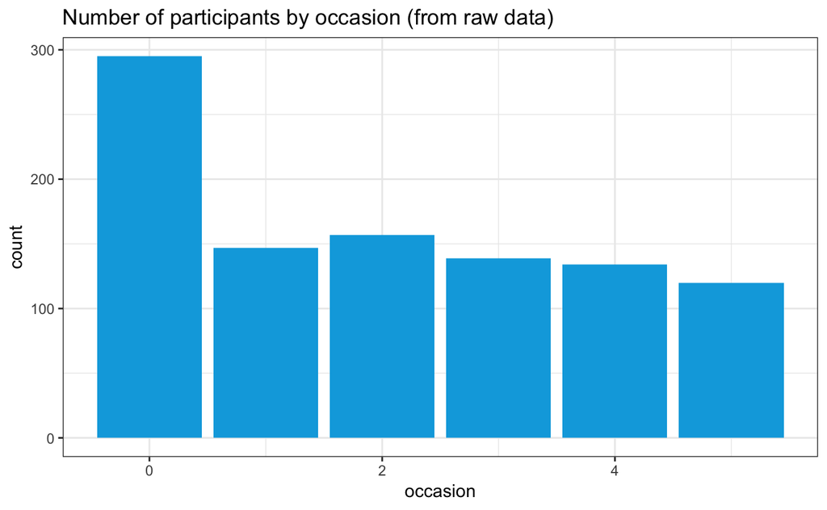

```r
# (2) Plot summary table:

# (a) Using raw data as input:
ggplot(df, aes(x = occasion)) +
  geom_bar(fill = seeblau) +
  labs(title = "Number of participants by occasion (from raw data)") +
  theme_bw()
```

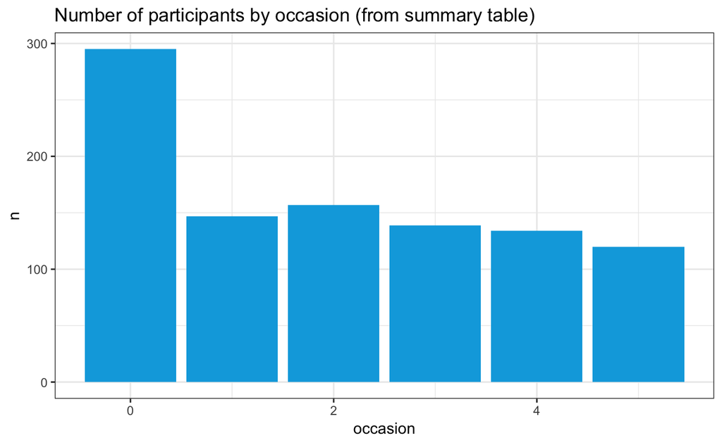

```r
# (b) Using id_by_occ from (1) as input:
ggplot(id_by_occ, aes(x = occasion)) +
  geom_bar(aes(y = n), stat = "identity", fill = seeblau) +
  labs(title = "Number of participants by occasion (from summary table)") +
  theme_bw()
```

Note the similarities and differences between these two bar plots. Although they look almost the same (except for the label on the y-axis and their title), they use completely different data as inputs. Which of the 2 plot versions would make it easier to add additional information (like error bars, a line indicating the mean counts of participants, or text labels showing the count values for each category)?

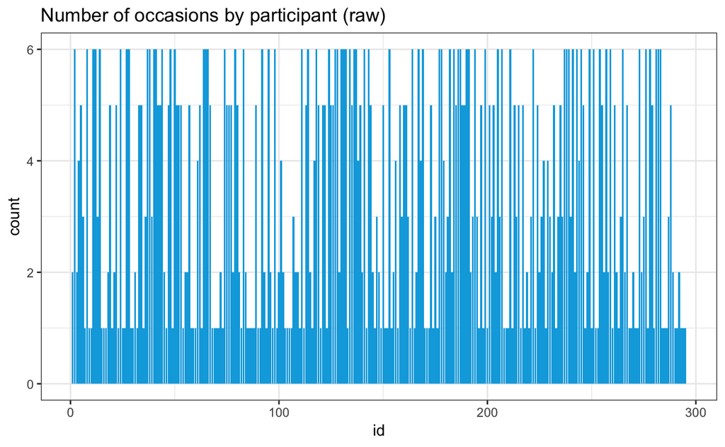

```r
# How many occasions are there for each participant?

# Data:
df <- AHI_CESD

# Graphical solution (with ggplot):
ggplot(df) +
  geom_bar(aes(x = id), fill = seeblau) +
  labs(title = "Number of occasions by participant (raw)") +
  theme_bw()
```

```r
# This does the trick, but looks messy.
# A cleaner solution uses 2 steps:

# (1) Summary table of grouped counts:
occ_by_id <- df %>%
  group_by(id) %>%
  count()
occ_by_id
```

```
#> # A tibble: 295 x 2
#> # Groups:   id [295]
#>       id     n
#>    <int> <int>
#>  1     1     2
#>  2     2     6
#>  3     3     2
#>  4     4     4
#>  5     5     5
#>  6     6     3
#>  7     7     1
#>  8     8     6
#>  9     9     1
#> 10    10     1
#> # ... with 285 more rows
```

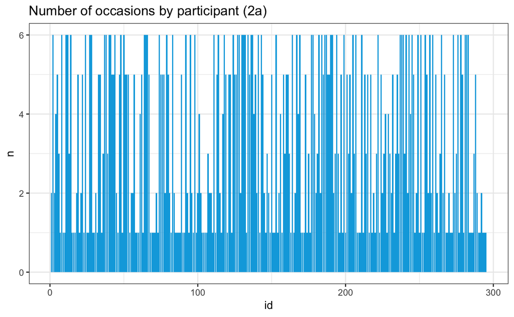

```r
# (2) Plot summary table:

# (a) re-create previous plot (by now from occ_by_id):
ggplot(occ_by_id) +
  geom_bar(aes(x = id, y = n), stat = "identity", fill = seeblau) +
  labs(title = "Number of occasions by participant (2a)") +
  theme_bw()
```

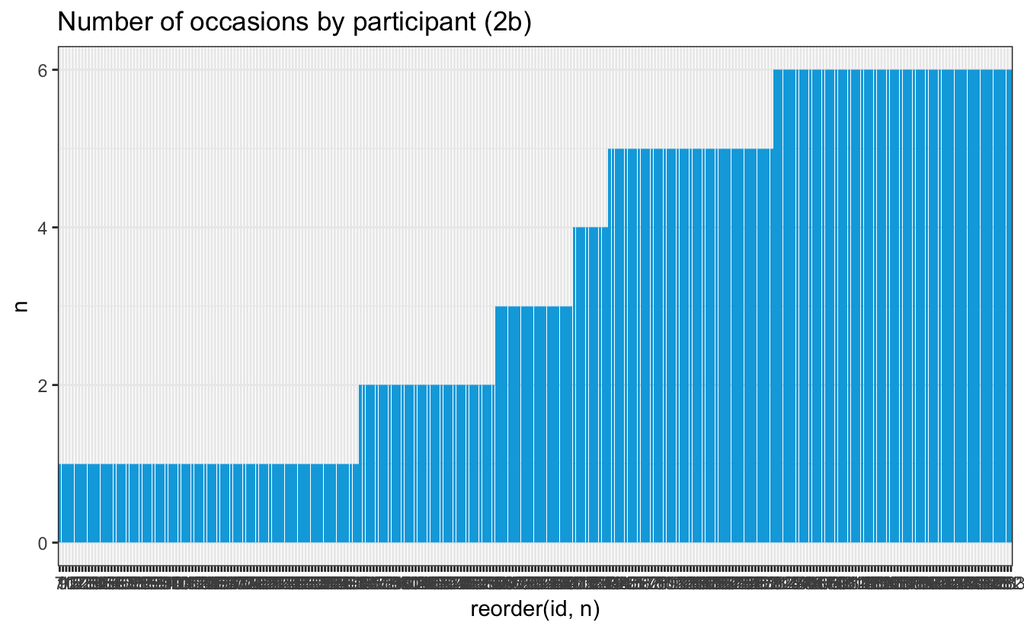

```r
# (b) reordering id by count n:
ggplot(occ_by_id) +
  geom_bar(aes(x = reorder(id, n), y = n), stat = "identity", fill = seeblau) +
  labs(title = "Number of occasions by participant (2b)") +
  theme_bw()
```

```r
# (c) more efficient solution:
occ_by_id_2 <- occ_by_id %>%
  arrange(n)
occ_by_id_2
```

```
#> # A tibble: 295 x 2
#> # Groups:   id [295]
#>       id     n
#>    <int> <int>
#>  1     7     1
#>  2     9     1
#>  3    10     1
#>  4    15     1
#>  5    16     1
#>  6    17     1
#>  7    20     1
#>  8    23     1
#>  9    25     1
#> 10    26     1
#> # ... with 285 more rows
```

```r
## (+) Add rownames (1:n) as a column:
# occ_by_id_2 <- rownames_to_column(occ_by_id_2)  # rowname is character variable!

## (+) Add a variable row that contains index of current row:
occ_by_id_2$row <- 1:nrow(occ_by_id_2)
occ_by_id_2
```

```
#> # A tibble: 295 x 3
#> # Groups:   id [295]
#>       id     n   row
#>    <int> <int> <int>
#>  1     7     1     1
#>  2     9     1     2
#>  3    10     1     3
#>  4    15     1     4
#>  5    16     1     5
#>  6    17     1     6
#>  7    20     1     7
#>  8    23     1     8
#>  9    25     1     9
#> 10    26     1    10
#> # ... with 285 more rows
```

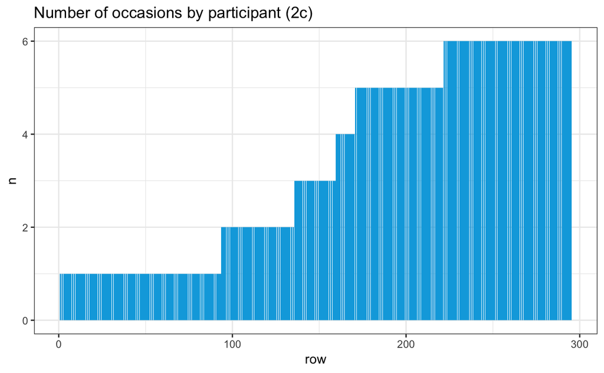

```r
ggplot(occ_by_id_2) +
  geom_bar(aes(x = row, y = n), stat = "identity", fill = seeblau) +
  labs(title = "Number of occasions by participant (2c)") +
  theme_bw()
```

Our exploration shows that every participant was measured on at least 1 and at most 6 occasions (check `range(occ_by_id$n)` to verify this). This raises two additional questions:

- Was every participant measured on occasion 0 (i.e., the *pre-test*)?
- Was every participant measured only *once* per occasion?

The first question may seem a bit picky, but do you really know that nobody showed up late (i.e., missed occasion 0) for the study? Actually, we do already know this, since we counted the number of participants and the number of participants per occasion above:

- the study sample contains 295 participants (check `nrow(posPsy_p_info)`), and
- the count of participants per occasion showed a value of 295 for occasion 0 in `id_by_occ`.

For the record, we testify that:

```r
nrow(posPsy_p_info)  # 295 participants
```

```
#> [1] 295
```

```r
id_by_occ$n[1]       # 295 participants counted (as n) in 1st line of id_by_occ
```

```
#> [1] 295
```

```r
nrow(posPsy_p_info) == id_by_occ$n[1]  # TRUE (qed)
```

```
#> [1] TRUE
```

To answer the second question, we can count the number of lines in `df` per `id` *and* `occasion` and then check whether any unexpected values (different from 1, i.e., `n != 1`) occur:

```r
# Summary table (with dplyr):
id_occ <- df %>%
  group_by(id, occasion) %>%
  count()
id_occ
```

```
#> # A tibble: 990 x 3
#> # Groups:   id, occasion [990]
#>       id occasion     n
#>    <int>    <int> <int>
#>  1     1        0     1
#>  2     1        1     1
#>  3     2        0     1
#>  4     2        1     1
#>  5     2        2     1
#>  6     2        3     1
#>  7     2        4     1
#>  8     2        5     1
#>  9     3        0     1
#> 10     3        2     1
#> # ... with 980 more rows
```

```r
summary(id_occ$occasion)
```

```
#>    Min. 1st Qu.  Median    Mean 3rd Qu.    Max.
#>   0.000   0.000   2.000   2.028   4.000   5.000
```

```r
summary(id_occ$n)  # Max is 2 (not 1)!
```

```
#>    Min. 1st Qu.  Median    Mean 3rd Qu.    Max.
#>   1.000   1.000   1.000   1.002   1.000   2.000
```

```r
# Do some occasions occur with other counts than 1?
id_occ %>%
  filter(n != 1)
```

```
#> # A tibble: 2 x 3
#> # Groups:   id, occasion [2]
#>      id occasion     n
#>   <int>    <int> <int>
#> 1     8        2     2
#> 2    64        4     2
```

```r
# => Participants with id of 8 and 64:
#    2 instances of occasion 2 and 4, respectively.
```

Importantly, 2 participants (8 and 64) are counted *twice* for an occasion (2 and 4, respectively).

Compare our counts of `id_by_occ` with **Table 1** (p. 4, of Woodworth et al., 2018), which also shows the number of participants who responded on each of the 6 measurement occasions): As the counts in this table correspond to ours, the repeated instances for some measurement occasions (which could indicate data entry errors, but also be due to large variability in the time inteval between measurements) were not reported in the original analysis (i.e., **Table 1**). This suggests that the 2 participants with repeated occasions were simply counted and measured twice on one occasion and missing from another one.

Another good question to ask is:

- How does the number of `elapsed.days` correspond to the measurement occasions?

This brings us to a more general principle and corresponding practice that involves different ways of viewing distributions of values.

## Viewing distributions

- **Principle 6:** Inspect the distributions of (continuous) variables.

Plotting the distribution of individual variables (e.g., with histograms or frequency polygons) provides a good overview over the values present in the data and any unusual or unexpected values.

### Histograms

A *histogram* provides a cumulative overview of a variable’s values along one dimension (see our examples in [visualizing data](http://rpository.com/ds4psy/essentials/visualize.html)). Here, we use a histogram of `elapsed.days` to address the question:

- How are the measurement times (`elapsed.days`) distributed overall (and relative to the stated times of each `occasion`)?

```r
## Data:
df <- AHI_CESD

# From Table 1 (p. 4):
occ_days <- c(0, 7, 14, 38, 98, 189)
names(occ_days) <- c("0: pre-test", "1: post-test", "2: 1-week", "3: 2-weeks", "4: 3-months", "5: 6-months")
occ_days
```

```
#>  0: pre-test 1: post-test    2: 1-week   3: 2-weeks  4: 3-months
#>            0            7           14           38           98
#>  5: 6-months
#>          189
```

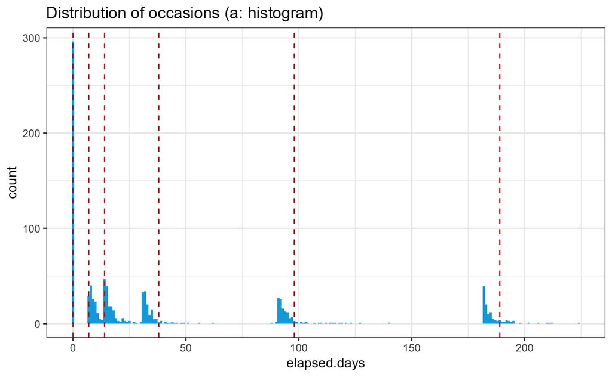

```r
# (a) Histogram:
ggplot(df, aes(x = elapsed.days)) +
  geom_histogram(fill = seeblau, binwidth = 1) +
  geom_vline(xintercept = occ_days, color = "firebrick", linetype = 2) +
  labs(title = "Distribution of occasions (a: histogram)") +
  theme_bw()
```

**Note:** The first 3 occasions are as expected. However, occasions 4 to 6 appear shifted to the left (i.e., were about 7 days earlier than stated).

### Alternative ways of viewing distributions

Alternative ways to plot cumulative distributions of values include *frequency polygons*, *density plots*, and *rug plots*.

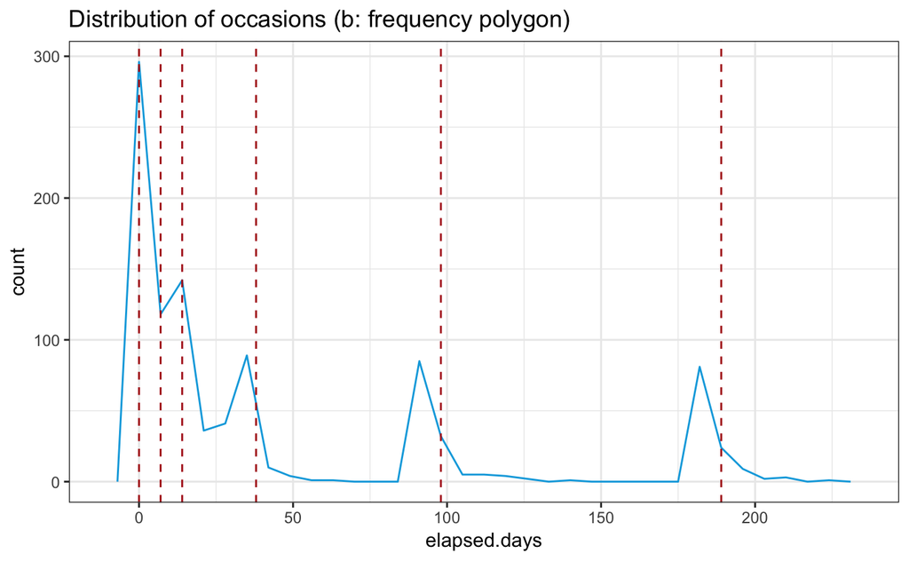

```r
# (b) frequency polygon:
ggplot(df, aes(x = elapsed.days)) +
  # geom_histogram(fill = seeblau, binwidth = 1) +
  geom_freqpoly(binwidth = 7, color = seeblau) +
  geom_vline(xintercept = occ_days, color = "firebrick", linetype = 2) +
  labs(title = "Distribution of occasions (b: frequency polygon)") +
  theme_bw()
```

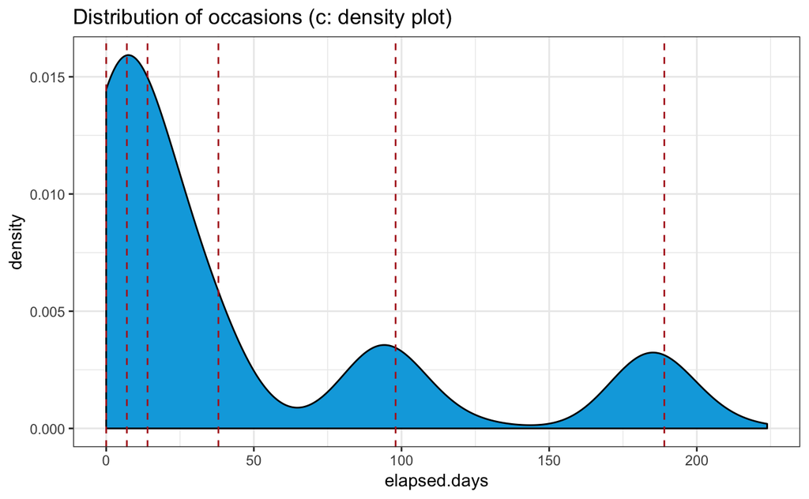

```r
# (c) density plot:
ggplot(df, aes(x = elapsed.days)) +
  # geom_histogram(fill = seeblau, binwidth = 1) +
  geom_density(fill = seeblau) +
  geom_vline(xintercept = occ_days, color = "firebrick", linetype = 2) +
  labs(title = "Distribution of occasions (c: density plot)") +
  theme_bw()
```

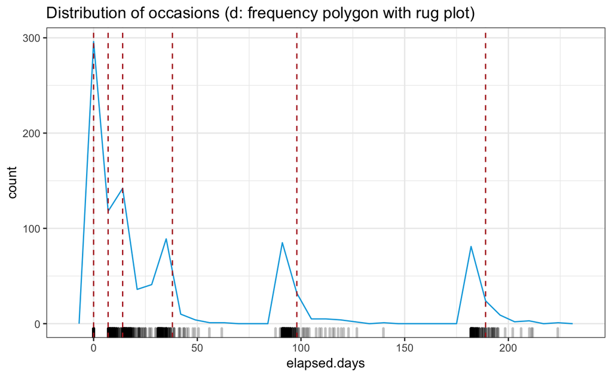

```r
# (d) rug plot:
ggplot(df, aes(x = elapsed.days)) +
  geom_freqpoly(binwidth = 7, color = seeblau) +
  geom_rug(size = 1, color = "black", alpha = 1/4) +
  geom_vline(xintercept = occ_days, color = "firebrick", linetype = 2) +
  labs(title = "Distribution of occasions (d: frequency polygon with rug plot)") +
  theme_bw()
```

## Filtering values

Once we have detected something noteworthy or strange, we may want to mark or exclude some observations (rows) or variables (columns). As we can easily select rows and filter cases (see `dplyr::select` and `dplyr::filter` in the last session), it may be good to create and include some dedicated filter variables in our data. Let’s use the participant data `posPsy_p_info` to illustrate how we can create filter variables and then filter cases:

```r
# Data:
p_info <- posPsy_p_info
dim(p_info)  # 295 x 6
```

```
#> [1] 295   6
```

In previous exercises (see [Exercise 5 of WPA02](http://rpository.com/ds4psy/essentials/visualize.html#exercise-5) and [Exercise 4 of WPA03](http://rpository.com/ds4psy/essentials/transform.html#exercise-4)), we answered the question:

- What is the `age` range of participants (overall and by `intervention`)?

by using both `ggplot` and `dplyr` pipes. For instance, we can answer questions about the distribution of `age` values by plotting histograms:

```r
# Age range:
range(p_info$age)
```

```
#> [1] 18 83
```

```r
summary(p_info$age)
```

```
#>    Min. 1st Qu.  Median    Mean 3rd Qu.    Max.
#>   18.00   34.00   44.00   43.76   52.00   83.00
```

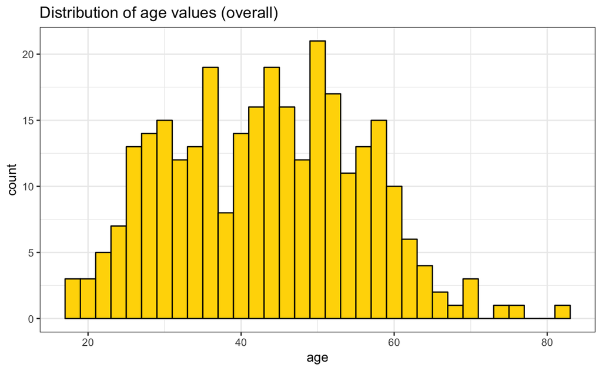

```r
# Histogramm showing the overall distribution of age
ggplot(p_info) +
  geom_histogram(mapping = aes(age), binwidth = 2, fill = "gold", col = "black") +
  theme_bw() +
  labs(title = "Distribution of age values (overall)")
```

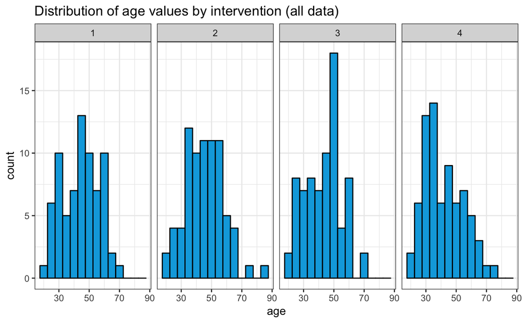

```r
# Create 4 histogramms showing the distribution of age by intervention:
ggplot(p_info) +
  geom_histogram(mapping = aes(age), binwidth = 5, fill = seeblau, col = "black") +
  theme_bw() +
  labs(title = "Distribution of age values by intervention (all data)") +
  facet_grid(.~intervention)
```

For practice purposes, suppose we only wanted to include participants up to an age of 70 years in some analysis. Rather than dropping these participants from the file, we can introduce a filter variable that is `TRUE` when some criterion (here: `age > 70`) is satisfied, and otherwise `FALSE`:

- **Principle 7:** Use filter variables to identify sub-sets of observations (rows).

```r
# How many participants are over 70?
sum(p_info$age > 70)  # 6 people with age > 70
```

```
#> [1] 6
```

```r
# Which ones?
which(p_info$age > 70)  #  51  83 114 155 215 244
```

```
#> [1]  51  83 114 155 215 244
```

```r
# Show their details (using dplyr):
p_info %>%
  filter(age > 70)
```

```
#> # A tibble: 6 x 6
#>      id intervention   sex   age  educ income
#>   <int>        <int> <int> <int> <int>  <int>
#> 1    51            2     1    83     2      2
#> 2    83            4     1    71     2      1
#> 3   114            1     1    71     4      1
#> 4   155            3     2    71     4      1
#> 5   215            4     1    75     3      2
#> 6   244            2     1    77     3      2
```

```r
# Add a corresponding filter variable to df:
p_info <- p_info %>%
  mutate(over_70 = (age > 70))

dim(p_info) # => 7 variables (now including over_70 as a logical variable):
```

```
#> [1] 295   7
```

```r
head(p_info)
```

```
#> # A tibble: 6 x 7
#>      id intervention   sex   age  educ income over_70
#>   <int>        <int> <int> <int> <int>  <int> <lgl>
#> 1     1            4     2    35     5      3 FALSE
#> 2     2            1     1    59     1      1 FALSE
#> 3     3            4     1    51     4      3 FALSE
#> 4     4            3     1    50     5      2 FALSE
#> 5     5            2     2    58     5      2 FALSE
#> 6     6            1     1    31     5      1 FALSE
```

```r
# Check details again (but applying filter to over_70):
p_info %>%
  filter(over_70)
```

```
#> # A tibble: 6 x 7
#>      id intervention   sex   age  educ income over_70
#>   <int>        <int> <int> <int> <int>  <int> <lgl>
#> 1    51            2     1    83     2      2 TRUE
#> 2    83            4     1    71     2      1 TRUE
#> 3   114            1     1    71     4      1 TRUE
#> 4   155            3     2    71     4      1 TRUE
#> 5   215            4     1    75     3      2 TRUE
#> 6   244            2     1    77     3      2 TRUE
```

In the present case, `filter(over_70)` is about as long and complicated as `filter(age > 70)` and thus not really necessary. However, defining explicit filter variables can pay off when constructing more complex filter conditions or when needing several sub-sets of the data (e.g., for cross-validation purposes). Given an explicit filter variable, we can later filter any analysis (or plot) on the fly:

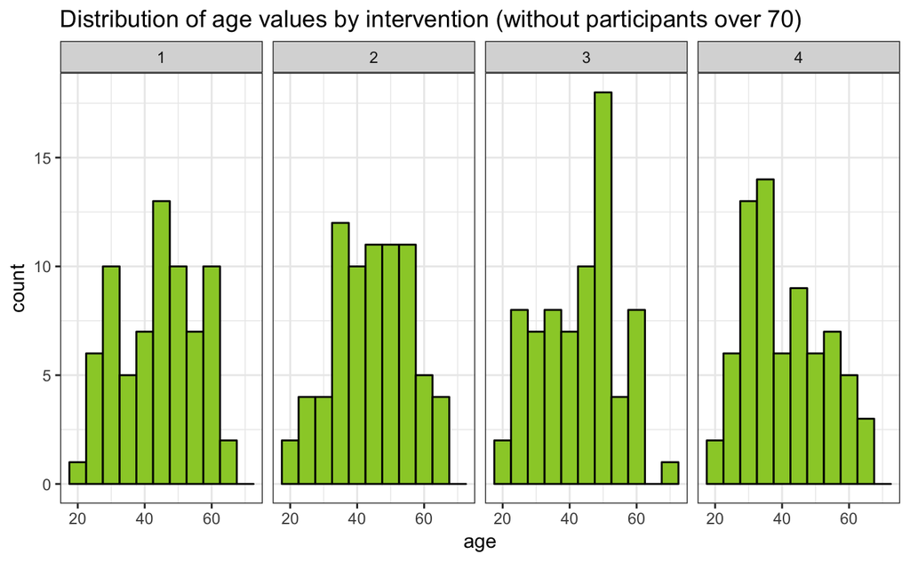

```r
# Age distribution of participants up to 70 (i.e., not over 70):
p_info %>%
  filter(over_70 == FALSE) %>%
  ggplot() +
  geom_histogram(mapping = aes(age), binwidth = 5, fill = "olivedrab3", col = "black") +
  theme_bw() +
  labs(title = "Distribution of age values by intervention (without participants over 70)") +
  facet_grid(.~intervention)
```

```r
# Alternatively, we can quickly create sub-sets of the data:
p_info_young <- p_info %>%
  filter(over_70 == FALSE)

p_info_old <- p_info %>%
  filter(over_70 == TRUE)

dim(p_info_young)  # 289 participants (295 - 6) x 7 variables
```

```
#> [1] 289   7
```

```r
dim(p_info_old)    #   6 participants           x 7 variables
```

```
#> [1] 6 7
```

## Viewing relationships

Most research hypotheses involve *relationships* or measures of *correspondence* between 2 or more variables. This brings us to another principle:

- **Principle 8:** Inspect relationships between (continuous or categorical) variables.

### Scatterplots

A scatterplot shows the relationship between 2 (typically continuous) variables:

```r
## Data:
df <- AHI_CESD
dim(df)
```

```
#> [1] 992  50
```

```r
df
```

```
#> # A tibble: 992 x 50
#>       id occasion elapsed.days intervention ahi01 ahi02 ahi03 ahi04 ahi05
#>    <int>    <int>        <dbl>        <int> <int> <int> <int> <int> <int>
#>  1     1        0         0               4     2     3     2     3     3
#>  2     1        1        11.8             4     3     3     4     3     3
#>  3     2        0         0               1     3     4     3     4     2
#>  4     2        1         8.02            1     3     4     4     4     3
#>  5     2        2        14.3             1     3     4     4     4     3
#>  6     2        3        32.0             1     3     4     4     4     4
#>  7     2        4        92.2             1     3     3     2     3     3
#>  8     2        5       182.              1     3     3     3     4     2
#>  9     3        0         0               4     3     3     2     4     2
#> 10     3        2        16.4             4     3     3     3     4     4
#> # ... with 982 more rows, and 41 more variables: ahi06 <int>, ahi07 <int>,
#> #   ahi08 <int>, ahi09 <int>, ahi10 <int>, ahi11 <int>, ahi12 <int>,
#> #   ahi13 <int>, ahi14 <int>, ahi15 <int>, ahi16 <int>, ahi17 <int>,
#> #   ahi18 <int>, ahi19 <int>, ahi20 <int>, ahi21 <int>, ahi22 <int>,
#> #   ahi23 <int>, ahi24 <int>, cesd01 <int>, cesd02 <int>, cesd03 <int>,
#> #   cesd04 <int>, cesd05 <int>, cesd06 <int>, cesd07 <int>, cesd08 <int>,
#> #   cesd09 <int>, cesd10 <int>, cesd11 <int>, cesd12 <int>, cesd13 <int>,
#> #   cesd14 <int>, cesd15 <int>, cesd16 <int>, cesd17 <int>, cesd18 <int>,
#> #   cesd19 <int>, cesd20 <int>, ahiTotal <int>, cesdTotal <int>
```

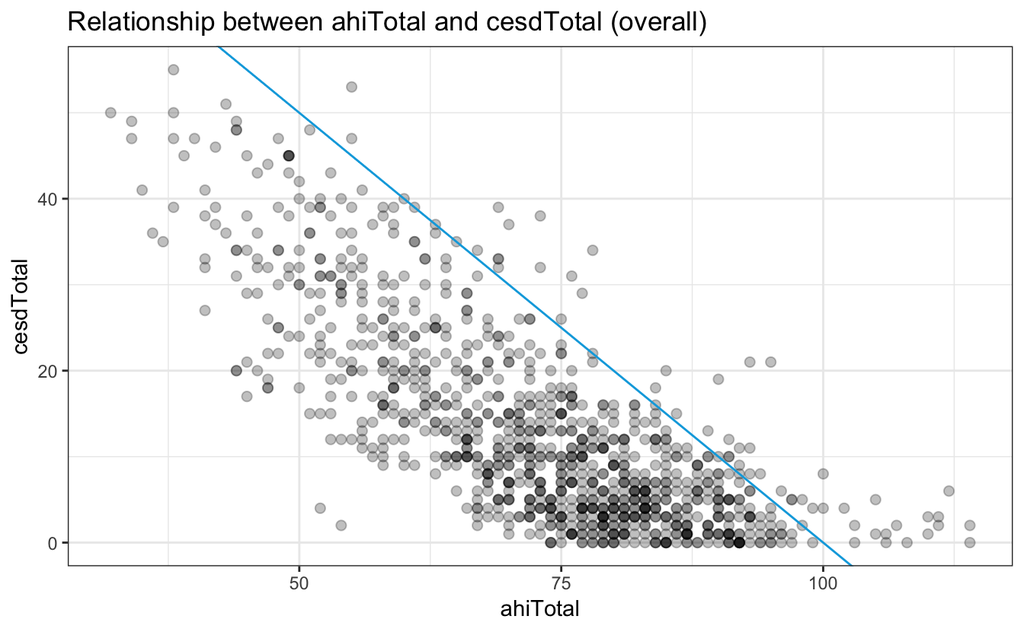

```r
ggplot(df) +
  geom_point(aes(x = ahiTotal, y = cesdTotal), size = 2, alpha = 1/4) +
  geom_abline(intercept = 100, slope = -1, col = seeblau) +
  labs(title = "Relationship between ahiTotal and cesdTotal (overall)",
       x = "ahiTotal", y = "cesdTotal") +
  theme_bw()
```

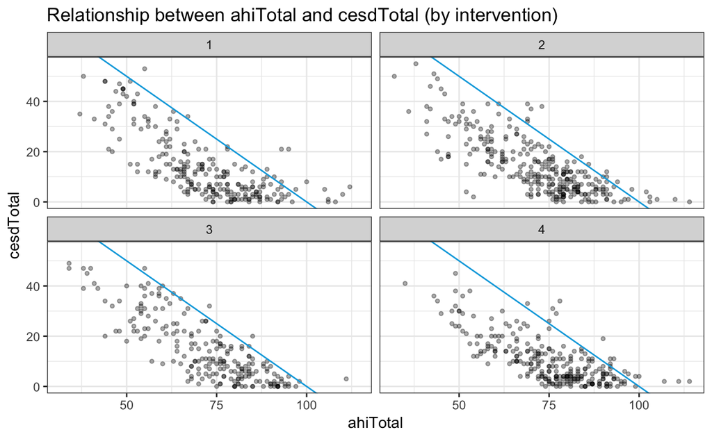

```r
ggplot(df) +
  geom_point(aes(x = ahiTotal, y = cesdTotal), size = 1, alpha = 1/3) +
  geom_abline(intercept = 100, slope = -1, col = seeblau) +
  labs(title = "Relationship between ahiTotal and cesdTotal (by intervention)",
       x = "ahiTotal", y = "cesdTotal") +
  facet_wrap(~intervention) +
  theme_bw()
```

### Violin and box plots

# More on EDA

- study `vignette("ggplot")` and the documentation for `ggplot` and various geoms (e.g., `geom_`);
- study https://ggplot2.tidyverse.org/reference/ and its examples;
- see the [cheat sheet on data visualization](https://www.rstudio.com/resources/cheatsheets/);
- read [Chapter 3: Data visualization](http://r4ds.had.co.nz/data-visualisation.html) and [Chapter 7: Exploratory data analysis (EDA)](http://r4ds.had.co.nz/exploratory-data-analysis.html) and complete their exercises.

# Conclusion

All [ds4psy](http://rpository.com/ds4psy/) essentials:

| Nr. | Topic |
| --- | --- |
| 0. | [Syllabus](http://rpository.com/ds4psy/) |
| 1. | [Basic R concepts and commands](http://rpository.com/ds4psy/essentials/basics.html) |
| 2. | [Visualizing data](http://rpository.com/ds4psy/essentials/visualize.html) |
| 3. | [Transforming data](http://rpository.com/ds4psy/essentials/transform.html) |
| 4. | **Exploring data (EDA)** |
| +. | [Datasets](http://rpository.com/ds4psy/essentials/datasets.html) |

[Last update on 2018-11-27 11:57:09 by [hn](http://neth.de/).]

[^1]: The participant part of this data has been used as `p_info` in the previous sessions.
[^2]: Actually, listing *everything* required to execute a file can get quite excessive (check out `sessionInfo()` or the `session_info` and `package_info` functions of `devtools`, in case you’re interested, and consider using the `packrat` package in case you want to preserve or share your current setup). Hence, most people only explicitly list and load non-standard packages (in their current version).